# A bug in libsvm to identify SVs

YingFu (dhlsfy@163.com) School of Business Administration, South China University of Technology Date: 10 Aug 2020

## Identify SVs based on sklearn

In the previous blog [What are support vectors in SVM](https://blankandwhite1.github.io/YingFu.github.io/MachineLearning/What%20are%20support%20vectors.html), we concluded that in the soft-margin SVM, if a point's Lagrange multiplier $\alpha_i\in(0,C)$, it must be a support vector, and in some special cases, if its Lagrange multiplier equal to C and zero it may also be a support vector.

we also give a classfication problem example with the following three points:

| $i$ | $ x^{i}_1 $ | $ x^{i}_2 $ | $ y^{i} $ |
| --- | --- | --- | --- |
| 1 | 1 | 0 | 1 |
| 2 | 0 | 0 | -1 |
| 3 | 0 | 1 | -1 |

In this example, we calculated that the Lagrange multiplier is $\alpha_1 = 2$, $\alpha_2 = 2$, $\alpha_3 = 0$, respectively. The decision boundary function is $2x^{i}_1-1=0$.

As we mentioned before, because the Lagrange multiplier $\mathbf{x}^{1}$ and $\mathbf{x}^{2}$ are both larger than $0$ and less than $C$. So $\mathbf{x}^{1}$ and $\mathbf{x}^{2}$ are both support vectors.

For $\mathbf{x}^{3}$, due to $y_3(2x^{3}_1-1)=-1*(0-1)=1$, so $\mathbf{x}^{3}$ is also a support vector.

Here is a simple implementation based on sklean(version: 0.23.1.) to identify the support vectors:

```python
import numpy as np
from sklearn import svm
from sklearn.datasets import make_blobs,make_circles
import matplotlib.pyplot as plt
plt.style.use('ggplot')
plt.rc('font',family='Times New Roman')


def plotSVM(X,y,clf,title):

    clf.fit(X, y)
    plt.scatter(X[:, 0], X[:, 1], c=y, s=30, cmap=plt.cm.Paired)

    # create grid to evaluate model
    minX,maxX = min(X[:,0]),max(X[:,0])
    minY,maxY = min(X[:,1]),max(X[:,1])
    plt.xlim((minX-0.2,maxX+0.2))
    plt.ylim((minY-0.2,maxY+0.2))
    xx = np.linspace(minX, maxX, 30)
    yy = np.linspace(minY, maxY, 30)
    YY, XX = np.meshgrid(yy, xx)


    # XX.ravel():  [xx[0,0] xx[0,1] ... xx[1,0] xx[1,1] ...]
    # after vstack:
    # [[xx[0,0] xx[0,1] ... xx[1,0] xx[1,1] ...]
    #   yy[0,0] yy[0,1] ... yy[1,0] yy[1,1] ...]]
    # after .T
    # [[xx[0,0] yy[0,0]]
    #  [xx[0,1] yy[0,1]]
    #  ... ]
    xy = np.vstack([XX.ravel(), YY.ravel()]).T
    Z = clf.decision_function(xy).reshape(XX.shape)

    # plot decision boundary and margins
    plt.contour(XX, YY, Z, colors='k', levels=[-1, 0, 1], alpha=0.5,
               linestyles=['--', '-', '--'])


    # plot support vectors
    plt.scatter(clf.support_vectors_[:, 0], clf.support_vectors_[:, 1], s=100,
               linewidth=1, color="b", facecolors='none')
    plt.title(title)
    plt.show()

    # Calculate the decision function value for each point
    decFuncVal = clf.decision_function(X[clf.support_])

    return clf
```

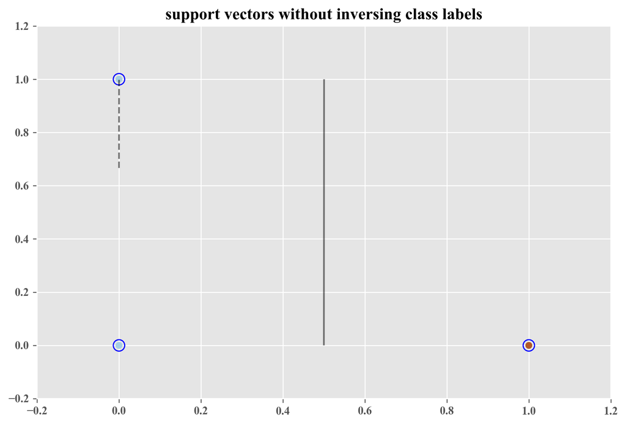

```python
X = np.array([[0,0],[0,1],[1,0]])
y = np.array([-1,-1,1])
# set C as large as possibel,
# soft-margin SVM approximately equals to hard-margin SVM
clf = svm.SVC(kernel='linear', C = 10000)
clf = plotSVM(X,y,clf = clf,title = 'support vectors without inversing class labels')
```

From the output of the implementation, both the three points are support vectors, which is consistent with our calculation.

However, in our example before, if we inverse each class label of each point, which means the three points with:

| $i$ | $ x^{i}_1 $ | $ x^{i}_2 $ | $ y^{i} $ |
| --- | --- | --- | --- |
| 1 | 1 | 0 | 1 |
| 2 | 0 | 0 | -1 |
| 3 | 0 | 1 | -1 |

after class label being inversed:

| $i$ | $ x^{i}_1 $ | $ x^{i}_2 $ | $ y^{i} $ |
| --- | --- | --- | --- |
| 1 | 1 | 0 | -1 |
| 2 | 0 | 0 | 1 |
| 3 | 0 | 1 | 1 |

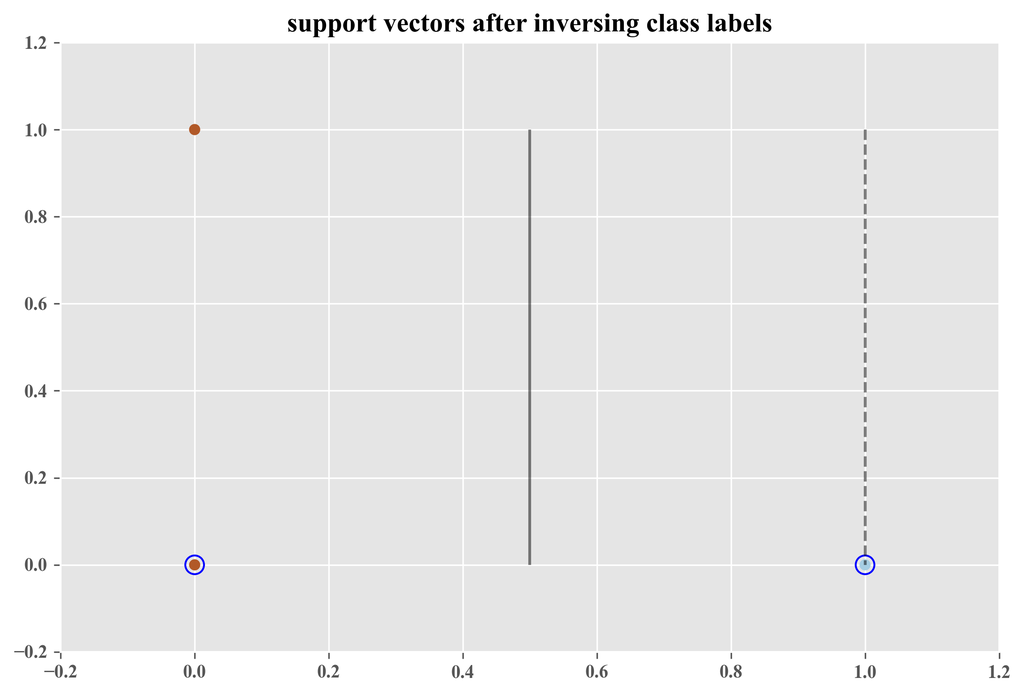

```python
X = np.array([[0,0],[0,1],[1,0]])
y = np.array([1,1,-1])
clf = svm.SVC(kernel='linear', C = 10000)
clf = plotSVM(X,y,clf = clf,title = 'support vectors after inversing class labels')
```

However, from the output of implementation, only $\mathbf{x}^{1}$ and $\mathbf{x}^{2}$ are support vectors, and $\mathbf{x}^{3}$ is not a support vectors.

To verify whether $\mathbf{x^3}$ is a support vector or not, we calculated based on the definition of SVM that the Lagrange multiplier is $\alpha_1 = 2$, $\alpha_2 = 2$, $\alpha_3 = 0$, respectively. The decision boundary function is $-2x^{i}_1+1=0$.

There is no doubt that $\mathbf{x}^{1}$ and $\mathbf{x}^{2}$ are support vectors. For $\mathbf{x}^{3}$, due to $y_3(-2x^{3}_1+1)= 1*(-0+1)=1$, so $\mathbf{x}^{3}$ is also a support vector.

The results of implementation based on sklearn is inconsistent with our calculation, there may be something wrong in sklearn.

(P.S: the calculation process is similar to the example in [What are support vectors in SVM (part 5)](https://blankandwhite1.github.io/YingFu.github.io/MachineLearning/What%20are%20support%20vectors.html).

## Libsvm

As we know that the implementatio of sklearn.svm.SVC() is based on libsvm(libsvm 3.23).

libsvm is popular open source machine learning libraries, developed by Chih-Chung Chang and Chih-Jen Lin in National Taiwan University and written in C++ though with a C API. The latest version is 3.24 released on September 11, 2019. We can download from the [libsvm homepage](https://www.csie.ntu.edu.tw/~cjlin/libsvm/)

### Usage of libsvm

1. Download the latest libsvm(3.24) from [libsvm homepage.](https://www.csie.ntu.edu.tw/~cjlin/libsvm/)
2. Unzip the downloaded files to an arbitrary directory.
3. Libsvm requires the format of training and testing data files is:  
   [label] [index1]:[value1] [index2]:[value2] ...

In our example, the format of traing data is:

| 1 | 1 | 1 | 2 | 0 |
| --- | --- | --- | --- | --- |
| -1 | 1 | 0 | 2 | 0 |
| -1 | 1 | 0 | 2 | 1 |

Save it as `libsvmE1.txt`

after class label being inversed, the format of training data is:

[output not shown]

Save it as `libsvmE2.txt`

1. Usage: svm-train [options] training_set_file [model_file]  
   Use the cmd command to enter the windows directory in the libsvm directory we unzipped, and use `svm-train` with the option `t 0` means the type of kernel function is linear function and `c 10000` means setting the parameter C of C-SVC to 10000.

`C:\Users\dhlsf\Downloads\libsvm-3.24\windows>svm-train.exe -t 0 -c 10000 C:\Users\dhlsf\Desktop\libsvmE1.txt`

The output may like this:

[figure not shown]

`iter` is the number of iterations  
`nu` is the parameters of selected kernel function  
`obj` is the optimal objective value of the dual SVM problem  
`rho` is the bias term in the decision function  
`nSV` and `nBSV` are number of support vectors and bounded support vectors (i.e., alpha_i = C)  
`Accuracy` is # correctly predicted data / # total testing data × 100%

This output indicates that there are 3 support vectors in our example.

Similarly, after class label being inversed, in the commend-line:

`C:\Users\dhlsf\Downloads\libsvm-3.24\windows>svm-train.exe -t 0 -c 10000 C:\Users\dhlsf\Desktop\libsvmE2.txt`

The output may like this:

[figure not shown]

This output indicates that there are only 2 support vectors in our example after class label of each points being reversed, the results implemented by `libsvm(3.24)` is consistent with `sklearn(libsvm 3.23)`, but inconsistant with the results we calculated by the definition of SVM.

It will be great chance there lies a bug in `libsvm 3.24`